# Table of Contents (Jupyter)

### 5.6.11 - Tuning Linear SVM

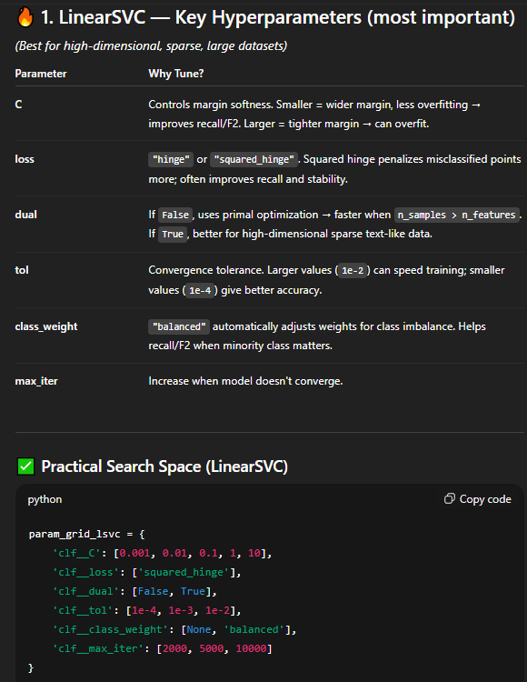

```python
from sklearn.svm import LinearSVC

model = Pipeline(steps=[
    ('preprocess', preprocessor),
    ("clf", LinearSVC(dual=False))
])


param_dist = {
    "clf__C": [0.01, 0.1, 1, 10, 100],
    "clf__loss": ["hinge", "squared_hinge"],
    "clf__dual": [False],
    "clf__class_weight": [None, "balanced"],
    "clf__tol": [1e-4, 1e-3, 1e-2]
}

search = RandomizedSearchCV(
    estimator=model,
    param_distributions=param_dist,
    n_iter=20,
    scoring=weighted_f2,
    n_jobs=-1,
    cv=5,
    verbose=1,
    random_state=42
)
search.fit(X_train, y_train)
print(search.best_params_)
print(search.best_score_)
```

```
Fitting 5 folds for each of 20 candidates, totalling 100 fits
{'clf__tol': 0.01, 'clf__loss': 'squared_hinge', 'clf__dual': False, 'clf__class_weight': None, 'clf__C': 0.01}
0.7388025106942926
```

[output not shown]

```python
# Create a new pipeline using the best params
tuned_model = Pipeline(steps=[
    ('preprocess', preprocessor),
    ('drop_high_vif', ColumnDropper(
            drop_cols=columns_to_drop,
            all_feature_names=X_train_scaled.columns,  # known feature names from preprocessor
            return_df=False                    # keep as numpy for sklearn models
        )),
    ("clf", LinearSVC(
            tol=0.01,
            loss='squared_hinge',
            dual=False,
            class_weight=None,
            C=0.01,
            random_state=42        # optional but recommended
    ))
])

trained_model = evaluate_model(len(models),"LinearSVM Tuned VIF Imbalanced",tuned_model, X_train, X_test, y_train, y_test)
models.append(trained_model)
```

```python
print(results[['Model','TestF2Score']].sort_values(by="TestF2Score", ascending=False))
```

```
                                    Model  TestF2Score
16        Logistic C=1/500 VIF Imbalanced     0.928405
23       SVCLinear Untuned VIF Imbalanced     0.922444
25           SVC RBF Tuned VIF Imbalanced     0.913947
18      RandomForest Tuned VIF Imbalanced     0.912365
19  GradientBoosting Tuned VIF Imbalanced     0.911271
15          Logistic Tuned VIF Imbalanced     0.906416
14        GradientBoosting VIF Imbalanced     0.901198
26         LinearSVM Tuned VIF Imbalanced     0.899941
0             Logistic Untuned Imbalanced     0.896367
21          LightGBM Tuned VIF Imbalanced     0.895657
17     Logistic Polynomial VIF Imbalanced     0.894674
2     GradientBoosting Untuned Imbalanced     0.892428
1         RandomForest Untuned Imbalanced     0.889090
20           XGBoost Tuned VIF Imbalanced     0.889090
12                Logistic VIF imbalanced     0.884110
22     NaiveBayes Gaussian VIF Imbalanced     0.877297
4             LightGBM Untuned Imbalanced     0.874317
13            RandomForest VIF Imbalanced     0.866788
3              XGBoost Untuned Imbalanced     0.865326
6              RandomForest Untuned SMOTE     0.843077
7             RandomForest Untuned ADASYN     0.838471
9           LightGBM Untuned is_unbalance     0.836420
10                  XGBoost Untuned SMOTE     0.828712
8           LightGBM Untuned class_weight     0.827671
11       XGBoost Untuned scale_pos_weight     0.818912
24         SVCLinear Tuned VIF Imbalanced     0.772613
5                  Logistic Untuned SMOTE     0.755076
```

```python
#Manually get the indexes of the best model for each algorithm.
# We will tune their thresholds to see if we can improve performance further.
top_models = {'logistic':{'model_id':16},
             'svclinear': {'model_id':23},
             'svcrbf':{'model_id':25},
             'rf':{'model_id':18},
             'gbm':{'model_id':14},
             'xgb':{'model_id':20},
}

#We will make use of models list that contains a tuple of (untrained pipeline, trained model)
# and results dataframe that has model names.
i=1
for model in top_models.values():
    print(f'{i}. {results.iloc[model['model_id']].Model} -> F2 Score: {results.iloc[model['model_id']].TestF2Score}')
    i+=1
```

```
1. Logistic C=1/500 VIF Imbalanced -> F2 Score: 0.9284051222351571
2. SVCLinear Untuned VIF Imbalanced -> F2 Score: 0.9224441833137486
3. SVC RBF Tuned VIF Imbalanced -> F2 Score: 0.913946587537092
4. RandomForest Tuned VIF Imbalanced -> F2 Score: 0.9123649459783914
5. GradientBoosting VIF Imbalanced -> F2 Score: 0.9011976047904192
6. XGBoost Tuned VIF Imbalanced -> F2 Score: 0.8890898131404461
```

## 5.7 - Tuning Thresholds

Till now, here are our top models (based on F2 score) for each model category

We will try to find optimal threshold

### 5.7.1 Find best thresholds for each of the top models

```python
import numpy as np
from sklearn.metrics import fbeta_score

def tune_threshold_on_validation(model, X_val, y_val, beta=2):
    """
    Tune the optimal threshold using ONLY the validation set.
    Avoids leakage from the test set.
    """

    thresholds = np.arange(0.0, 1.001, 0.01)
    y_prob = model.predict_proba(X_val)[:, 1]

    best_thresh = 0.0
    best_fbeta = -1

    for t in thresholds:
        y_pred = (y_prob >= t).astype(int)
        fbeta = fbeta_score(y_val, y_pred, beta=beta)

        if fbeta > best_fbeta:
            best_fbeta = fbeta
            best_thresh = t

    return best_thresh, best_fbeta
```

```python
#We cannot use trained models as they were created using full X_train data
#Thus for threshold tuning, we must use X_train_cv for training the models AGAIN,
# and then use X_val for tuning

#In models list, we have stored a tuple (untrained_pipeline, trained_model).
# So for threshold tuning we will utilize untrained_pipeline to train models just on
# the X_train_cv data and use X_val for threshold tuning


for key, model in top_models.items():
    model_id = model['model_id']
    untrained_pipeline = clone(models[model_id][0])
    untrained_pipeline.fit(X_train_cv, y_train_cv)
    best_thresh, best_f2_val = tune_threshold_on_validation(
        untrained_pipeline, X_val, y_val, beta=2
    )
    model_name = results.iloc[model_id].Model
    print(f'Best threshold {model_name}:{best_thresh}, gives F2 score as {best_f2_val}')

    #We store the best threshold in same dictionary so that we can use it later for creating Threshold based classifiers.
    top_models[key]['Threshold']= best_thresh
    #Add threshold as a string to model name
    top_models[key]['NewModelName'] = model_name+" Thresh "+str(best_thresh)
    #Add the trained model to the dictionary
    top_models[key]['TrainedModel'] = untrained_pipeline


print(top_models)
```

```
Best threshold Logistic C=1/500 VIF Imbalanced:0.48, gives F2 score as 0.9253903990746096
Best threshold SVCLinear Untuned VIF Imbalanced:0.44, gives F2 score as 0.9262485481997678
Best threshold SVC RBF Tuned VIF Imbalanced:0.44, gives F2 score as 0.9227594339622641
Best threshold RandomForest Tuned VIF Imbalanced:0.34, gives F2 score as 0.9316588785046729
Best threshold GradientBoosting VIF Imbalanced:0.35000000000000003, gives F2 score as 0.9272300469483568
```

[output not shown]

[output cut: 89 more lines]

[output not shown]

### 5.7.2 Creating Models based on best thresholds.

- To create a model that uses a custom threshold, we don’t change the classifier itself.
- We can simply wrap the trained model + threshold into a small helper class that applies the threshold every time we call predict().

```python
from sklearn.base import BaseEstimator, ClassifierMixin, clone

class ThresholdClassifier(BaseEstimator, ClassifierMixin):
    def __init__(self, model=None, threshold=0.5):
        self.model = model          # underlying model (pipeline)
        self.threshold = threshold  # decision threshold
        self.named_steps = model.named_steps

    def fit(self, X, y=None):
        # Clone the internal model so pipeline doesn't get overwritten
        self.model_ = clone(self.model)
        self.model_.fit(X, y)
        return self

    def predict_proba(self, X):
        return self.model_.predict_proba(X)

    def predict(self, X):
        y_prob = self.model_.predict_proba(X)[:, 1]
        return (y_prob >= self.threshold).astype(int)

    def get_params(self, deep=True):
        return {
            "model": self.model,
            "threshold": self.threshold,
        }

    def set_params(self, **params):
        for key, value in params.items():
            setattr(self, key, value)
        return self
```

```python
# Wrap the model into ThreholdClassifer class

for key, model in top_models.items():
    final_model = ThresholdClassifier(model['TrainedModel'], threshold=model['Threshold'])
    trained_model = evaluate_model(len(models),model['NewModelName'],final_model,X_train, X_test, y_train, y_test)
    #We dont have any untrained pipeline (and neither do we care, so just put dummy string for the first value in the tuple)
    models.append(trained_model)
```

```python
results[['Model','TestF2Score']].sort_values(by="TestF2Score", ascending=False)
```

|  | Model | TestF2Score |
| --- | --- | --- |
| 28 | SVCLinear Untuned VIF Imbalanced Thresh 0.44 | 0.929487 |
| 16 | Logistic C=1/500 VIF Imbalanced | 0.928405 |
| 27 | Logistic C=1/500 VIF Imbalanced Thresh 0.48 | 0.927865 |
| 32 | XGBoost Tuned VIF Imbalanced Thresh 0.3 | 0.926143 |
| 30 | RandomForest Tuned VIF Imbalanced Thresh 0.34 | 0.924839 |
| 23 | SVCLinear Untuned VIF Imbalanced | 0.922444 |
| 31 | GradientBoosting VIF Imbalanced Thresh 0.35000... | 0.921362 |
| 25 | SVC RBF Tuned VIF Imbalanced | 0.913947 |
| 18 | RandomForest Tuned VIF Imbalanced | 0.912365 |
| 19 | GradientBoosting Tuned VIF Imbalanced | 0.911271 |
| 29 | SVC RBF Tuned VIF Imbalanced Thresh 0.44 | 0.908824 |
| 15 | Logistic Tuned VIF Imbalanced | 0.906416 |
| 14 | GradientBoosting VIF Imbalanced | 0.901198 |
| 26 | LinearSVM Tuned VIF Imbalanced | 0.899941 |
| 0 | Logistic Untuned Imbalanced | 0.896367 |
| 21 | LightGBM Tuned VIF Imbalanced | 0.895657 |
| 17 | Logistic Polynomial VIF Imbalanced | 0.894674 |
| 2 | GradientBoosting Untuned Imbalanced | 0.892428 |
| 20 | XGBoost Tuned VIF Imbalanced | 0.889090 |
| 1 | RandomForest Untuned Imbalanced | 0.889090 |
| 12 | Logistic VIF imbalanced | 0.884110 |
| 22 | NaiveBayes Gaussian VIF Imbalanced | 0.877297 |
| 4 | LightGBM Untuned Imbalanced | 0.874317 |
| 13 | RandomForest VIF Imbalanced | 0.866788 |
| 3 | XGBoost Untuned Imbalanced | 0.865326 |
| 6 | RandomForest Untuned SMOTE | 0.843077 |
| 7 | RandomForest Untuned ADASYN | 0.838471 |
| 9 | LightGBM Untuned is_unbalance | 0.836420 |
| 10 | XGBoost Untuned SMOTE | 0.828712 |
| 8 | LightGBM Untuned class_weight | 0.827671 |
| 11 | XGBoost Untuned scale_pos_weight | 0.818912 |
| 24 | SVCLinear Tuned VIF Imbalanced | 0.772613 |
| 5 | Logistic Untuned SMOTE | 0.755076 |

Our winners have changed.

```python
#Manually get the indexes of the best model for each algorithm.
# We will tune their thresholds to see if we can improve performance further.
top_models = {
    'svclinear': {'model_id':28},
    'logistic':{'model_id':27},
    'xgb':{'model_id':32},
    'rf':{'model_id':30},
    'gbm':{'model_id':31},
    'svcrbf':{'model_id':25},

}

i=1
for model in top_models.values():
    print(f'{i}. {results.iloc[model['model_id']].Model} -> F2 Score: {results.iloc[model['model_id']].TestF2Score}')
    i+=1
```

```
1. SVCLinear Untuned VIF Imbalanced Thresh 0.44 -> F2 Score: 0.9294871794871795
2. Logistic C=1/500 VIF Imbalanced Thresh 0.48 -> F2 Score: 0.9278650378126818
3. XGBoost Tuned VIF Imbalanced Thresh 0.3 -> F2 Score: 0.9261430246189918
4. RandomForest Tuned VIF Imbalanced Thresh 0.34 -> F2 Score: 0.9248385202583675
5. GradientBoosting VIF Imbalanced Thresh 0.35000000000000003 -> F2 Score: 0.9213615023474179
6. SVC RBF Tuned VIF Imbalanced -> F2 Score: 0.913946587537092
```

## 5.8 Comparison of Model Results

### 5.8.1 Choose the candidates

[figure not shown]

### 5.8.2 Precision Recall Curve

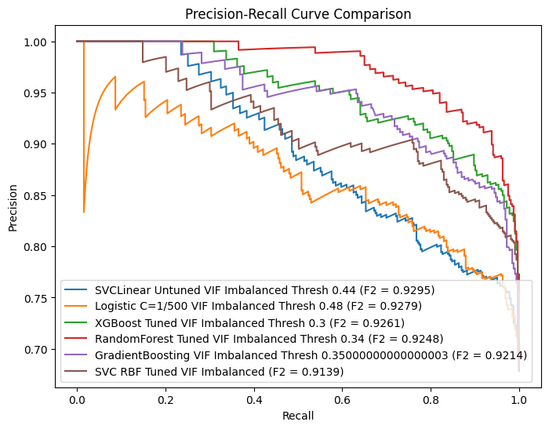

```python
from sklearn.metrics import precision_recall_curve

plt.figure(figsize=(8,6))


for model in top_models.values():
    model_id = model['model_id']
    model_name = results.iloc[model_id].Model
    f2Score = results.iloc[model_id].TestF2Score

    y_probs = models[model_id][1].predict_proba(X_val)[:, 1]
    precision, recall, _ = precision_recall_curve(y_val, y_probs)
    plt.plot(recall, precision, label=f'{model_name} (F2 = {f2Score:.4f})')



plt.xlabel('Recall')
plt.ylabel('Precision')
plt.title('Precision-Recall Curve Comparison')
plt.legend(loc='lower left')
plt.show()
```

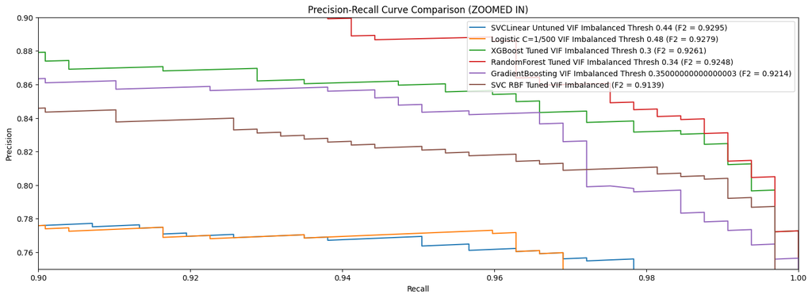

```python
from sklearn.metrics import precision_recall_curve

plt.figure(figsize=(18,6))


for model in top_models.values():
    model_id = model['model_id']
    model_name = results.iloc[model_id].Model
    f2Score = results.iloc[model_id].TestF2Score

    y_probs = models[model_id][1].predict_proba(X_val)[:, 1]
    precision, recall, _ = precision_recall_curve(y_val, y_probs)
    plt.plot(recall, precision, label=f'{model_name} (F2 = {f2Score:.4f})')



plt.xlabel('Recall')
plt.ylabel('Precision')
plt.title('Precision-Recall Curve Comparison (ZOOMED IN)')
plt.legend(loc='upper right')

# 🔍 Zoom-in on recall axis
plt.xlim(0.90, 1)
plt.ylim(0.75, 0.9)
plt.show()
```

SVCLinear Untuned VIF Imbalanced Thresh 0.44 is our top model

The PR curve shows RandomForest looks “better” visually,. but our F2 Score shows SVCLinear, Logistic and XGBoost to be top 3

This can happen because a single metric (like F2) summarizes the precision-recall tradeoff at one selected threshold, while the PR curve shows performance across all thresholds.

- **F2 score emphasizes recall:**
- It was calculated for one chosen decision threshold (in our chart, those thresholds are 0.48, 0.35, etc.). We evaluating how each model performs at that specific cutoff.
- **Precision-Recall (PR) curve:**
- It depicts the behavior across all thresholds. A model might have a smoother, more favorable curve overall, meaning it offers better flexibility or potential after threshold tuning even if at default threshold, its F2 score is lower.
- **So, RandomForest might produce more favorable tradeoffs across various thresholds, but at particular threshold choices we had for SVCLinear, Logistic and XGBoost, they have slightly better F2 score.**

### 5.8.3 Choosing the best model

Since the SVC Linear, Logistic Regression, and tree-based models (XGBoost, Random Forest) have very similar F₂ scores, the decision should rest on model assumptions, interpretability, and robustness rather than the tiny performance difference.

#### 5.8.3.1 Testing for assumptions for SVCLinear Model

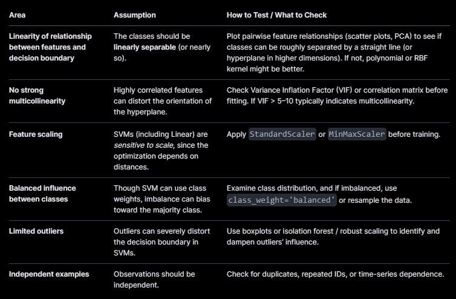

**Linearity assumption not supported by PCA plots**

- Our PCA (2D & 3D) visualizations clearly show nonlinear mixing between churn and non-churn classes — clusters overlap and curve into each other.
- This indicates the decision boundary is not linear, meaning a linear hyperplane (as used by Linear SVC) cannot separate the data effectively.
- As a result, Linear SVC is likely oversimplifying the true relationship, reducing its generalization potential even if the F₂ scores appear momentarily good. ✅ Reject SVC Linear because: The class separability structure is nonlinear — visually and likely functionally — violating SVC Linear’s core assumption.

#### 5.8.3.2 Testing for assumptions for Logistic Regression

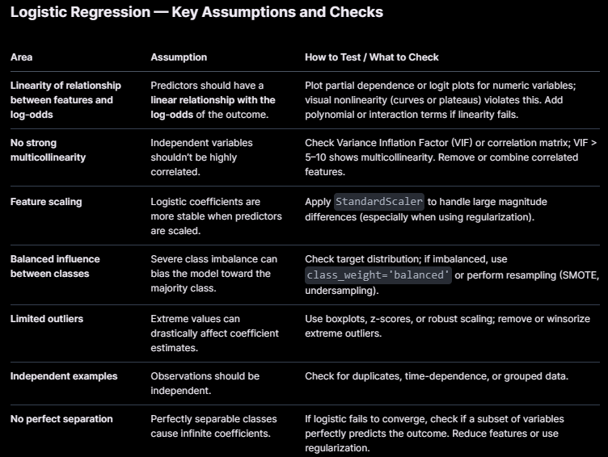

**Linearity Assumption Violated (Same as Linear SVC)**

- Logistic Regression assumes a linear relationship between the predictors and the log-odds of the target.
- PCA plots show the classes are nonlinearly intertwined, meaning no linear boundary can cleanly separate them.
- Because of this, the model can only draw a "flat plane" (hyperplane) between classes — which cuts through the mixed region instead of wrapping around the patterns.
- Reject Reason: The data’s structure clearly violates the core linearity assumption that Logistic Regression rests on. Performance parity with tree models occurs by coincidence, not because of proper fit.

**Polynomial Features Did Not Help → Indicates Intrinsic Nonlinearity**

- Expanding Logistic Regression with polynomial features up to a certain degree (say 2 or 3) should have improved discrimination if the interactions were polynomially related.
- We found no F₂ gain despite polynomial terms, it suggests that:
  - The true boundary is highly nonlinear (not captured even by moderate polynomial terms).
  - The logistic optimizer is plateauing — it’s already at the expressive limit of linear + low-degree polynomial space.
- Reject Reason: Failure of polynomial feature engineering to improve Logistic Regression confirms that the underlying decision surface is structurally nonlinear (e.g., complex, piecewise, or tree-like patterns).

**Poor Fit with Class Imbalance and Complex Interactions**

- Logistic Regression tends to degrade in imbalanced data scenarios — small variations in thresholds or sampling can severely shift recall and precision.
- It also cannot naturally handle feature interactions (e.g., “tenure × department” or “salary growth × engagement”) unless explicitly engineered.
- Given that Gradient Boosting and XGBoost perform similarly without manual feature interactions, that signals the linear model isn’t capturing subtler churn patterns — the tree-based ones are.
- Reject Reason: Logistic Regression’s inability to implicitly learn interactions limits its adaptability to real-world churn data, which usually involves interaction-driven attrition behavior.

**Predictive Performance Plateau + Non-Interpretability Tradeoff**

- Yes, Logistic gives great interpretability through coefficients, but:
- That interpretability is only meaningful if the functional form (log-odds linearity) holds true.
- In our case, since the feature–outcome relationship is nonlinear, the coefficients are not reliable explanations of churn risk magnitude — possibly misleading business readers.
- Reject Reason: When assumptions break, the interpretability advantage of Logistic Regression no longer holds — “interpretable nonsense” is worse than a complex but accurate model.

#### 5.8.3.3 Testing for assumptions for XGBoost

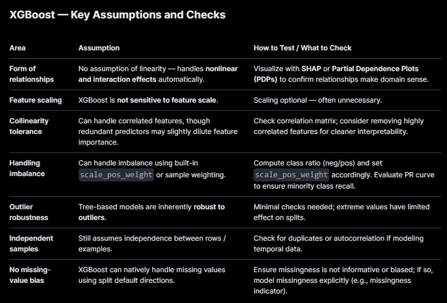

1. We removed highly correlated features using VIF RFE
2. We already tested fixing class imbalance
3. No duplicates
4. Samples are per driver, so independent
5. There are not much assumptions related to distribution, linearity

#### 5.8.3.4 Testing for assumptions for Random Forest

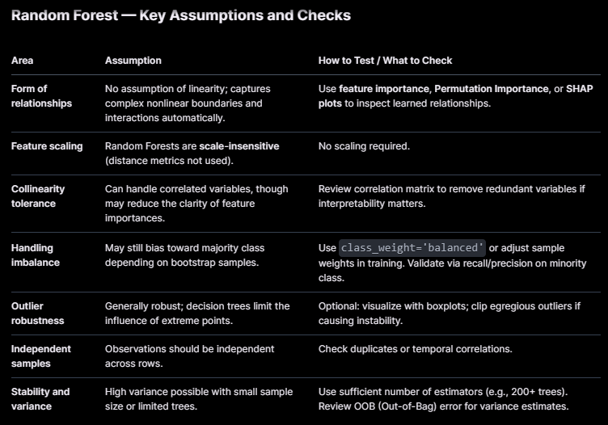

- Like XGBoost, Random Forest doesn’t have strict statistical assumptions (no need for linearity, scaling, or independence between features)

#### 5.8.3.5 Final Choice

We choose XGBoost as it has no strict assumptions, as is performing almost similar to the Linear models.

```python
final_models = {
    'xgb':{'model_id':32},
    # 'rf':{'model_id':30},
}
```

Plot feature importances for all models

- What this does:
  - Automatically detects if it’s a tree-based or linear model.
  - Extracts feature names from ColumnTransformer if present.
  - Sorts features by importance.
  - Plots a horizontal bar graph for clarity.

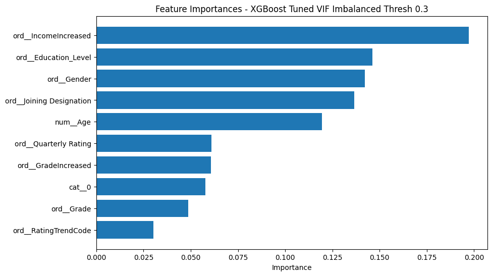

```python
def get_importances(model, model_name):
    """
    Returns a DataFrame with columns:
    [feature, importance, model]
    """
    clf = model.named_steps['clf']
    # 1. Tree-based models
    if hasattr(clf, "feature_importances_"):
        imp = clf.feature_importances_

    # 2. Linear models with coef_
    elif hasattr(clf, "coef_"):
        imp = np.abs(clf.coef_.ravel())   # take absolute values

    # 3. SVC(kernel='rbf') → no importances
    else:
        return pd.DataFrame()   # skip models that don’t support


    # Get feature names from ColumnTransformer
    try:
        preprocessor = model.named_steps['preprocess']
        feature_names = preprocessor.get_feature_names_out()
    except:
        # fallback if get_feature_names_out not available
        feature_names = [f'feature_{i}' for i in range(len(imp))]

    # Sort features by importance
    indices = np.argsort(imp)[::-1]
    sorted_features = [feature_names[i] for i in indices]
    sorted_importances = imp[indices]

    df = pd.DataFrame({
        "feature": sorted_features,
        "importance": sorted_importances,
        "model": model_name
    })
    return df


def plot_feature_importances(model, model_name):
    """
    Plots feature importances or coefficients for a pipeline model,
    using actual feature names from ColumnTransformer if available.
    """
    try:

        df_imp = get_importances(model, model_name)


        # Plot horizontal bar chart
        plt.figure(figsize=(10,6))
        plt.barh(df_imp.feature, df_imp.importance)
        plt.xlabel('Importance')
        plt.title(f'Feature Importances - {model_name}')
        plt.gca().invert_yaxis()  # highest importance at top
        plt.show()
        return df_imp

    except Exception as e:
        print(f"Error plotting {model_name}: {e}")



dfs = []
for model in final_models.values():
    model_id = model['model_id']
    model_name = results.iloc[model_id].Model
    #The function plot_feature_importances plots the features and
    # returs a dataframe
    #We shall use this dataframe for further analysis.
    dfs.append(plot_feature_importances(models[model_id][1],model_name))

#Convert the list dfs to a dataframe
all_feat_df = pd.concat(dfs, ignore_index=True)
```

### 5.8.3 Feature × Model Matrix to compare features

We use pivot table

```python
feat_matrix = all_feat_df.pivot_table(
    index="feature",
    columns="model",
    values="importance",
    fill_value=0
)

feat_matrix
```

| model feature | XGBoost Tuned VIF Imbalanced Thresh 0.3 |
| --- | --- |
| cat__0 | 0.057662 |
| num__Age | 0.119562 |
| ord__Education_Level | 0.146113 |
| ord__Gender | 0.142247 |
| ord__Grade | 0.048792 |
| ord__GradeIncreased | 0.060829 |
| ord__IncomeIncreased | 0.197153 |
| ord__Joining Designation | 0.136584 |
| ord__Quarterly Rating | 0.060900 |
| ord__RatingTrendCode | 0.030158 |

```python
rank_df = feat_matrix.rank(ascending=False)
rank_df.sort_values(by='XGBoost Tuned VIF Imbalanced Thresh 0.3', inplace=True)
rank_df
```

| model feature | XGBoost Tuned VIF Imbalanced Thresh 0.3 |
| --- | --- |
| ord__IncomeIncreased | 1.0 |
| ord__Education_Level | 2.0 |
| ord__Gender | 3.0 |
| ord__Joining Designation | 4.0 |
| num__Age | 5.0 |
| ord__Quarterly Rating | 6.0 |
| ord__GradeIncreased | 7.0 |
| cat__0 | 8.0 |
| ord__Grade | 9.0 |
| ord__RatingTrendCode | 10.0 |

## 5.9 Final Model analysis

### 5.9.1 Problem Summary

We built a predictive model to estimate driver attrition risk. Reducing false negatives (drivers who leave but are predicted to stay) was the main business priority.

### 5.9.3 Model Selection Process

- We chose XGBoost based classifier after following steps.
  - ✔ Trained multiple models (LogReg, SVC, RandomForest, XGB, LGBM, NaiveBayes, LinearSVM)
  - ✔ Compared across validation folds
  - ✔ Evaluation metric - F2 score was chosen as Recall is more important in our use case of Employee Churn
  - ✔ Tuning - RandomizedSearchCV was used, followed by Threshold tuning
- Results
  - 32 models were benchmarked using the same preprocessing pipeline.

```python
# Columns to include in the markdown table
cols = [
    "ModelID", "Model",
    "TrainF2Score", "ValF2Score", "TestF2Score",
    "TrainRecall", "ValRecall", "TestRecall",
    "TrainF1Score", "ValF1Score", "TestF1Score",
    "TrainPrecision", "ValPrecision", "TestPrecision",
    "TrainAccuracy", "ValAccuracy", "TestAccuracy",
]

# Create markdown table
table_df = results[cols]
# Sort by best TestF2
table_df = table_df.sort_values("TestF2Score", ascending=False)

md_table = table_df.to_markdown(index=False)

# Print to copy into your report
print(md_table)
```

```
|   ModelID | Model                                                      |   TrainF2Score |   ValF2Score |   TestF2Score |   TrainRecall |   ValRecall |   TestRecall |   TrainF1Score |   ValF1Score |   TestF1Score |   TrainPrecision |   ValPrecision |   TestPrecision |   TrainAccuracy |   ValAccurac…
|----------:|:-----------------------------------------------------------|---------------:|-------------:|--------------:|--------------:|------------:|-------------:|---------------:|-------------:|--------------:|-----------------:|---------------:|----------------:|----------------:|-------------…
|        28 | SVCLinear Untuned VIF Imbalanced Thresh 0.44               |       0.909887 |     0.909886 |      0.929487 |      0.964396 |    0.964386 |     0.984568 |       0.838776 |     0.83879  |      0.857527 |         0.742111 |       0.742152 |        0.759524 |        0.748424 |      0.74842…
|        16 | Logistic C=1/500 VIF Imbalanced                            |       0.915502 |     0.915492 |      0.928405 |      0.974458 |    0.974449 |     0.984568 |       0.839333 |     0.839323 |      0.855228 |         0.737119 |       0.737117 |        0.755924 |        0.746849 |      0.74684…
|        27 | Logistic C=1/500 VIF Imbalanced Thresh 0.48                |       0.917005 |     0.916994 |      0.927865 |      0.978328 |    0.978322 |     0.984568 |       0.838196 |     0.838186 |      0.854083 |         0.733179 |       0.733177 |        0.754137 |        0.743697 |      0.74369…
|        32 | XGBoost Tuned VIF Imbalanced Thresh 0.3                    |       0.935754 |     0.935752 |      0.926143 |      0.985293 |    0.98528  |     0.975309 |       0.870131 |     0.870148 |      0.861035 |         0.779073 |       0.779119 |        0.770732 |        0.80042  |      0.80041…
|        30 | RandomForest Tuned VIF Imbalanced Thresh 0.34              |       0.94234  |     0.942352 |      0.924839 |      0.989163 |    0.989147 |     0.972222 |       0.879867 |     0.87993  |      0.861833 |         0.792323 |       0.792475 |        0.773956 |        0.816702 |      0.8167 …
|        23 | SVCLinear Untuned VIF Imbalanced                           |       0.907759 |     0.907751 |      0.922444 |      0.959752 |    0.959741 |     0.969136 |       0.83954  |     0.839541 |      0.860274 |         0.74609  |       0.746112 |        0.773399 |        0.75105  |      0.75105…
|        31 | GradientBoosting VIF Imbalanced Thresh 0.35000000000000003 |       0.925568 |     0.925539 |      0.921362 |      0.968265 |    0.968253 |     0.969136 |       0.868144 |     0.868103 |      0.857923 |         0.786789 |       0.786743 |        0.769608 |        0.80042  |      0.80042…
|        25 | SVC RBF Tuned VIF Imbalanced                               |       0.926476 |     0.926457 |      0.913947 |      0.963621 |    0.963602 |     0.950617 |       0.875835 |     0.875836 |      0.863955 |         0.802712 |       0.80277  |        0.791774 |        0.814601 |      0.81459…
|        18 | RandomForest Tuned VIF Imbalanced                          |       0.929269 |     0.929251 |      0.912365 |      0.955881 |    0.955856 |     0.938272 |       0.89202  |     0.892031 |      0.876081 |         0.836161 |       0.836255 |        0.821622 |        0.842962 |      0.84296…
|        19 | GradientBoosting Tuned VIF Imbalanced                      |       0.915099 |     0.915063 |      0.911271 |      0.942723 |    0.942704 |     0.938272 |       0.876574 |     0.876567 |      0.873563 |         0.819108 |       0.819245 |        0.817204 |        0.819853 |      0.81984…
|        29 | SVC RBF Tuned VIF Imbalanced Thresh 0.44                   |       0.931008 |     0.931001 |      0.908824 |      0.971361 |    0.971345 |     0.953704 |       0.876398 |     0.876419 |      0.848901 |         0.798352 |       0.798439 |        0.764851 |        0.814075 |      0.81407…
|        15 | Logistic Tuned VIF Imbalanced                              |       0.905956 |     0.90595  |      0.906416 |      0.955882 |    0.955871 |     0.950617 |       0.840137 |     0.840144 |      0.847318 |         0.749395 |       0.74943  |        0.764268 |        0.753151 |      0.75315…
|        14 | GradientBoosting VIF Imbalanced                            |       0.915236 |     0.915198 |      0.901198 |      0.942723 |    0.942704 |     0.929012 |       0.876888 |     0.876865 |      0.862464 |         0.819655 |       0.819729 |        0.804813 |        0.820378 |      0.82037…
```

[output cut: 20 more lines]

```
- SVCLinear and Logistic Regression outperformed even ensemble models in F2 score and overall stability across folds.
- However they had very similar scores, so we chose to go with Tree based models like XGBoost as they have very minimal assumptions and are thus FUTURE safe.
- Therefore, XGBoost was selected as the final model.
```

## 5.10 🧮 Model Performance Summary — XGBoost Tuned VIF Imbalanced (Threshold = 0.3)

| Metric | Training | Validation | Test |
| --- | --- | --- | --- |
| **F2 Score** | 0.9358 | 0.9358 | 0.9261 |
| **Recall** | 0.9853 | 0.9853 | 0.9753 |
| **F1 Score** | 0.8701 | 0.8701 | 0.8610 |
| **Precision** | 0.7791 | 0.7791 | 0.7707 |
| **Accuracy** | 0.8004 | 0.8004 | 0.7862 |

**Key takeaways**

- The **high recall (≈ 0.98 train/val, 0.97 test)** demonstrates strong churn‑capture capability, aligning with the recall‑weighted F₂ focus.
- A slight test‑set drop in F₂ ( ≈ 0.93 → 0.926 ) indicates mild generalization loss, acceptable for this problem context.
- Precision around 0.77 ensures that most predicted churners are indeed at risk — a reasonable balance for retention targeting.

#### Classification Report

```python
xgb_model = models[32][1]
from sklearn.metrics import classification_report, confusion_matrix

# Predicted labels and probabilities
y_pred = xgb_model.predict(X_test)
y_proba = xgb_model.predict_proba(X_test)[:, 1]

# Classification report
print("🔹 Classification Report (XGBoost):\n")
print(classification_report(y_test, y_pred, digits=3))

# print confusion matrix
print("\n🔹 Confusion Matrix:")
print(confusion_matrix(y_test, y_pred))
```

```
🔹 Classification Report (XGBoost):

              precision    recall  f1-score   support

           0      0.881     0.386     0.536       153
           1      0.771     0.975     0.861       324

    accuracy                          0.786       477
   macro avg      0.826     0.680     0.699       477
weighted avg      0.806     0.786     0.757       477


🔹 Confusion Matrix:
[[ 59  94]
 [  8 316]]
```

#### ROC AUC Curve

```
🔹 ROC–AUC Score: 0.8388
```

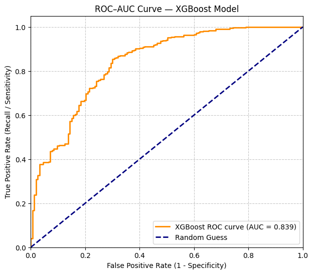

```python
from sklearn.metrics import roc_curve, auc

# Compute ROC
fpr, tpr, thresholds = roc_curve(y_test, y_proba)
roc_auc = auc(fpr, tpr)
print(f"\n🔹 ROC–AUC Score: {roc_auc:.4f}")

# Plot ROC curve
plt.figure(figsize=(7,6))
plt.plot(fpr, tpr, color='darkorange', lw=2,
         label=f'XGBoost ROC curve (AUC = {roc_auc:.3f})')
plt.plot([0, 1], [0, 1], color='navy', lw=2, linestyle='--', label='Random Guess')
plt.xlim([0.0, 1.0])
plt.ylim([0.0, 1.05])
plt.xlabel('False Positive Rate (1 - Specificity)')
plt.ylabel('True Positive Rate (Recall / Sensitivity)')
plt.title('ROC–AUC Curve — XGBoost Model')
plt.legend(loc='lower right')
plt.grid(True, linestyle='--', alpha=0.7)
plt.show()
```

#### 🧭 **Interpretation — ROC–AUC Curve (XGBoost)**

The ROC–AUC curve gives a very clear snapshot of how well the **XGBoost churn model** discriminates between “churners” and “non‑churners.”

##### **1️⃣ Overall Model Quality**

- The **AUC = 0.839** indicates that the model has **strong discriminative ability**.
- This means that on average, the model will **rank a randomly chosen churner higher than a non‑churner ~84 % of the time**.
- For business problems like churn prediction, *AUC ≥ 0.80* is considered **very good** — the model successfully distinguishes likely leavers from stayers.

##### **2️⃣ Shape of the Curve**

- The **orange ROC curve** rises steeply toward the top‑left corner, where **True‑Positive Rate (recall)** is high and **False‑Positive Rate** is low.
- This steep initial rise signifies that the model captures a large proportion of actual churners early (high sensitivity) while keeping false alarms moderate — desirable behavior in recall‑weighted settings like churn.
- The **blue diagonal line** represents random guessing (AUC = 0.5). Your curve being well above this line confirms meaningful predictive power.

##### **3️⃣ Trade‑off Interpretation**

- As thresholds loosen (moving right along the x‑axis), recall increases but false positives also rise.
- Operationally: the company can **choose a threshold** that offers the preferred recall–precision trade‑off (for instance, favoring recall to catch most possible churners at the cost of some false alerts).

##### **✅ Summary**

| Aspect | Interpretation |
| --- | --- |
| **AUC = 0.839** | Strong ability to distinguish churn vs non‑churn |
| **Curve steepness near origin** | High sensitivity achievable without major spike in false positives |
| **Compared to random (AUC = 0.5)** | +68 % performance lift over random guessing |
| **Business suitability** | Excellent fit for recall‑focused, retention‑driven models like employee / driver churn |

In short:

> **The XGBoost model demonstrates robust predictive performance (AUC = 0.839)** — it effectively ranks churn probabilities and can be confidently used for retention strategy planning and threshold‑based intervention design.

## 🌳 Feature Importance – XGBoost Tuned VIF Imbalanced (Threshold = 0.3)

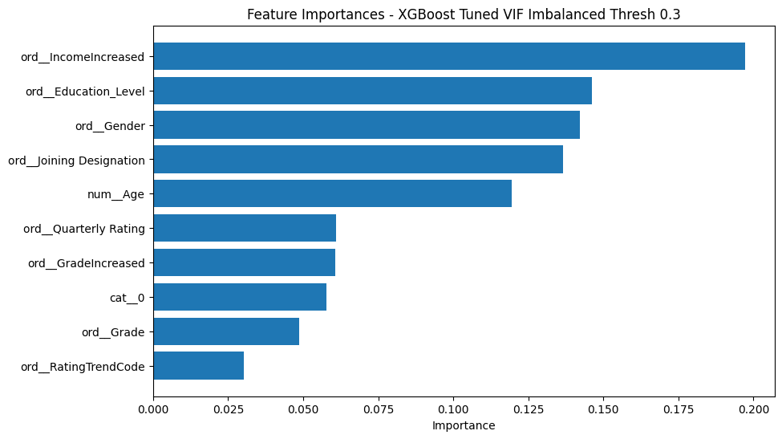

✅ **Conclusion**  
The **XGBoost Tuned VIF Imbalanced (Threshold = 0.3)** model achieves the best compromise between recall‑optimized performance and interpretable feature hierarchy. Income progression and career‑trajectory variables are the dominant churn drivers, providing actionable HR levers for retention initiatives.

# 6. Actionable Insights & Recommendations

## 6.1 Summary of Observations from EDA

[figure not shown]

## 6.2 Insights from EDA

- Churn and City
  - In 4 of the top 5 employing cities (C20,C22,C26,C27), the employee count DECREASED over the last two years
  - Only in one of the top 5 cities, C29 has the count increased. And infact, this increase is maximum across cities
  - For C20 the driver count has decreased the maximum
  - Cities C22, C7, C27 and C12 have lower attrition rates and stable number of drivers.
  - Cities C20, C29, C25, C17, C1 have very high volatility in driver count.
  - Churn is similar across education levels
  - **800+ people left the organization in each of the past 2 years (2019 and 2020). Considering that total strength of company is less than 800 drivers, that is big number.**
- **Monthly attrition rate is 8.45%. Yearly attrition rate is 65.4%**
- Churn and joining designation
- Drivers joining at Grade 1 and Grade 5 have highest chance of churning, around 73%
- Drivers joining at Grade 3 have lowest chance of churning, around 55%
- Churn and current grade are related
- **Drivers at Grade 1 have an extremely high chance of churn, 80%. Company can focus on this grade**
- Drivers Grade 4 have lowest chance of churning, around 50%, Grade 3.4,5 have overall lower churning chance, around 50-54%
- Drivers who churned have a substantially lower range of total business value
- Churn and Total Business Value
  - The average total business value of drivers who churned is one-third (33lakh) of those who did not churn (123 lakh)
- Churn and Quarterly rating
  - **88% of those who churned had the lowest quarterly rating of 1. It is possible company terminated their services due to the poor rating**
  - Those who have rating greater than 1 have a greater chance of staying
  - **Drivers who have consistently low ratings have 86% of chance of churn**
  - Drivers who have consistently high ratings have only 29% of chance of churn
  - Drivers whose rating has been seen as improving over the months stay with the company 86% of times
  - **ALL drivers whose rating declined were found to have churned**.
- Churn and Income Increase
  - **Almost all the drivers who churned did not have a increase in income over the months**.
  - This does not mean that all those who did not see increase in income got churned. That figure is 69%
  - **93% of drivers who saw an increase in income stayed**.
- Churn and Grade
  - **Among those whose grade did not increase since joining, 71% left the company**
  - Among those whose grade increased since joining, only 54% left the company
  - **86% of drivers who left the company were those that didnt see increase in their grade since joining**
- 68% of drivers have churned over the past years.

## 6.3 **Insights from the Learned Model and Their Effects**

🌳 Feature Importance – XGBoost Tuned VIF Imbalanced (Threshold = 0.3)

[output not shown]

## 6.4 Conclusions

### 6.4.1 📊 **Conclusions from Exploratory Data Analysis (EDA)**

#### 🧩 **Overall Attrition Profile**

- Attrition is **exceptionally high** — monthly 8.45 %, yearly ≈ 65 %.
- Over **800 employees left in each of 2019 and 2020**, exceeding total active headcount (< 800); attrition clearly outpaces hiring.
- **68 % of drivers** have churned over past years → systemic retention issue.

#### 🏙️ **City‑Level Patterns**

- **C20, C22, C26, C27** saw declines in driver count; **C29** alone expanded sharply (and shows strong volatility).
- **C22, C7, C27, C12** maintain *lower attrition and stable driver base* → potential best‑practice cities.
- **C20, C29, C25, C17, C1** show *high count volatility*, implying management or demand instability.

#### 🎓 **Joining Designation & Grade**

- **Highest churn (≈ 73 %)** among drivers joining at **Grade 1 and Grade 5**; **Grade 3** shows lowest churn (~ 55 %).
- **Current Grade 1** drivers face ≈ 80 % churn risk — clear focus segment for interventions.
- **No grade growth = 71 % churn** vs **grade improvement = 54 % churn** → promotion trajectory strongly influences retention.
- **83 % of drivers** had no grade increase over 2 years.

#### 💰 **Income & Compensation**

- **98 % of drivers saw no salary increase** in > 2 years.
- **93 % of those receiving an income increase stayed**; non‑increased earners have ~ 69 % churn probability.
- Salary stagnation is **the single strongest churn driver**.

#### 📈 **Performance (Ratings & Trends)**

- **88 % of churned drivers had lowest rating = 1**; consistently low ratings → 86 % churn probability.
- **All drivers with declining rating trends eventually churned.**
- Only **~1.5 %** improved their rating over time; improvement correlates strongly with retention (86 % stay).
- Overall rating distribution is heavily bottom‑weighted (≈ 73 % rated 1).

#### 💼 **Business Value Contribution**

- **Average total business value** of churned drivers = ₹ 33 L vs ₹ 123 L for stayers → churn severely impacts revenue.
- **14 % of drivers contribute 80 %+ of total business value** → classic **Pareto distribution**.
- **30 % of drivers contribute zero** business value, often short‑tenured or already exited.
- City C20 has the highest share of zero‑value drivers (≈ 7 %).
- Zero‑value active drivers (mainly new joins in 2020) may indicate **data gaps or unbilled records**.

#### 👥 **Demographics**

- **Mean age ≈ 33 years;** half of drivers 29‑37.
- Older groups (≥ 39 yrs) generate **2–3× higher business value** than younger cohorts → experience = productivity.
- Balanced gender ratio (59 % M / 41 % F) is positive; females tend to have **higher stable ratings** and *fewer downward performance trends*.
- Male drivers dominate in degrading‑rating category → behavior/performance issue to review.

#### 🎯 **Hiring and Tenure Trends**

- Hiring peaked in 2018, modestly declined but stays above pre‑2018 levels.
- **67 % joined within last year**, **82 % within 2 years**, **95 % within 5 years** — tenure is extremely low.
- In July 2020 (post‑pandemic), 1464 joined but 1616 left → attrition offset > 100 % of hiring.
- Majority of workforce is newly hired, which contributes to continual training & productivity loss.

#### 🎓 **Education Patterns**

- Roughly even split across education categories (10 +, 12 +, Graduate).
- **Higher education → higher average income** but churn similarity suggests other factors (growth & pay increase) dominate retention.

#### 💡 **Summary**

1. **Attrition is critical and structural**, not cyclical — exceeding sustainable thresholds.
2. **Income stagnation, lack of promotion, and poor performance ratings** emerge as the three dominant churn drivers.
3. **City‑specific volatility** (esp. C20 and C29) shows localized operational or management challenges.
4. **Business impact of churn is severe** — churners generate ⅓ of the value of stayers; losing top 14 % drivers risks disproportionate revenue loss.
5. The company’s workforce is **highly young and short‑tenured**, limiting institutional learning and service consistency.
6. **Performance management system is skewed** toward low ratings; rating compression masks true differentiation.

## 6.5 🧭 **Recommendations**

### **1. Compensation & Growth**

- Introduce **structured income progression** (e.g., quarterly pay‑review or incentive tier) to combat salary stagnation.
- Implement **clear grade‑promotion pathways**, linking them to measurable performance and tenure.

### **2. Performance Management**

- Redesign rating system with **broader distribution** and clearer feedback to avoid over‑concentration at low scores.
- Launch **coaching programs** for repeatedly low‑rated drivers; intervene early on declining‑trend alerts.
- Reward consistent improvement → build positive reinforcement cycle.

### **3. Targeted Retention Programs**

- **Prioritize Grade 1 and Grade 5** segments for retention initiatives — these are high‑risk joiners.
- **Protect the 14 % high‑value drivers** through tailored retention bonuses and engagement touchpoints.

### **4. City‑Specific Action**

- Audit local operations in **C20 and C29** to identify volatility causes (demand fluctuations, management gaps, partner issues).
- Replicate stable‑city practices from **C22 and C27**.

### **5. Data & Measurement**

- Investigate **zero business value records** for active drivers — likely data pipeline or billing issues.
- Strengthen **data tracking for income revisions** and **performance trend logs** for analytical continuity.

### **6. Workforce Strategy**

- Address high short‑tenure by enhancing **onboarding, mentorship, and reward structures** to improve first‑year retention.
- Explore **city‑specific hiring intensity adjustments** based on local churn velocity.

✅ **Bottom Line:**  
The exploratory analysis shows that churn is driven not by demographics but by **economic and developmental stagnation**.  
Reinforcing **income mobility, promotion transparency, and localized retention strategies** can substantially reduce attrition and safeguard the company’s top‑performing 14 % drivers who produce the majority of business value.

## 6.6 Questionnaire

Self note: Use https://wysiwyghtml.com/ for writing html with ease

### 6.6.1. What percentage of drivers have received a quarterly rating of 5?

Ratings are only from 1 to 4. Rating 5 is not present

### 6.6.2. Comment on the correlation between Age and Quarterly Rating.

**RatingMean**

Olders drivers have slightly more mean rating than younger ones, but the correlation of age and rating is very weak

**RatingTrend**

### 6.6.3. Name the city which showed the most improvement in Quarterly Rating over the past year

```python
# Approach
# Question asks improvement in quarterly driver_rating.  We need to understand what it means
# For each driver, we can find the rating at start of the year and their final rating.
# We then find the difference
# Then we sum these across cities.
# We can then find the city that has the maximum rating increase.

#We need only folloiwng columns for the analysis
# ['MMM-YY', 'Driver_ID', 'City','Quarterly Rating']

# Lets find last year rows
df_original =pd.read_csv("ola_driver_scaler.csv")
df_original['MMM-YY'] = pd.to_datetime(df_original['MMM-YY'], format='%m/%d/%y')

max_date = df_original['MMM-YY'].max()
cutoff_date = max_date - pd.Timedelta(days=365)

df_past_year = df_original[df_original['MMM-YY'] > cutoff_date][['MMM-YY', 'Driver_ID', 'City','Quarterly Rating']]
df_past_year
```

|  | MMM-YY | Driver_ID | City | Quarterly Rating |
| --- | --- | --- | --- | --- |
| 3 | 2020-11-01 | 2 | C7 | 1 |
| 4 | 2020-12-01 | 2 | C7 | 1 |
| 6 | 2020-01-01 | 4 | C13 | 1 |
| 7 | 2020-02-01 | 4 | C13 | 1 |
| 8 | 2020-03-01 | 4 | C13 | 1 |
| ... | ... | ... | ... | ... |
| 19099 | 2020-08-01 | 2788 | C27 | 3 |
| 19100 | 2020-09-01 | 2788 | C27 | 3 |
| 19101 | 2020-10-01 | 2788 | C27 | 2 |
| 19102 | 2020-11-01 | 2788 | C27 | 2 |
| 19103 | 2020-12-01 | 2788 | C27 | 2 |

9396 rows × 4 columns

```python
# We plan to group by driver and then use first and last rows in the group to find teh quarterly rating change
# Sorting order is important thus.
# Lets make sure we have dates sorted for each driver
df_past_year.sort_values(by=['Driver_ID','MMM-YY'], inplace=True)
df_rating_imp = df_past_year.groupby(['Driver_ID','City'], as_index=False).agg(
        QuarterlyRating_First=('Quarterly Rating', 'first'),
        QuarterlyRating_Last=('Quarterly Rating', 'last')
    )
df_rating_imp['RatingChange'] = df_rating_imp.eval('QuarterlyRating_Last-QuarterlyRating_First')
df_rating_imp
```

|  | Driver_ID | City | QuarterlyRating_First | QuarterlyRating_Last | RatingChange |
| --- | --- | --- | --- | --- | --- |
| 0 | 2 | C7 | 1 | 1 | 0 |
| 1 | 4 | C13 | 1 | 1 | 0 |
| 2 | 6 | C11 | 1 | 2 | 1 |
| 3 | 8 | C2 | 1 | 1 | 0 |
| 4 | 11 | C19 | 1 | 1 | 0 |
| ... | ... | ... | ... | ... | ... |
| 1546 | 2779 | C26 | 1 | 1 | 0 |
| 1547 | 2781 | C23 | 1 | 4 | 3 |
| 1548 | 2784 | C24 | 3 | 4 | 1 |
| 1549 | 2785 | C9 | 1 | 1 | 0 |
| 1550 | 2788 | C27 | 1 | 2 | 1 |

1551 rows × 5 columns

```python
#Finally lets group by cities and aggregate the gains and losses in RatingChange
df_city_ratings_change = df_rating_imp.groupby('City',as_index=False).RatingChange.sum()
df_city_ratings_change
```

|  | City | RatingChange |
| --- | --- | --- |
| 0 | C1 | -10 |
| 1 | C10 | -1 |
| 2 | C11 | 1 |
| 3 | C12 | 9 |
| 4 | C13 | 2 |
| 5 | C14 | -3 |
| 6 | C15 | -6 |
| 7 | C16 | -7 |
| 8 | C17 | -1 |
| 9 | C18 | 11 |
| 10 | C19 | 4 |
| 11 | C2 | 3 |
| 12 | C20 | 12 |
| 13 | C21 | 13 |
| 14 | C22 | 5 |
| 15 | C23 | 4 |
| 16 | C24 | 5 |
| 17 | C25 | -9 |
| 18 | C26 | -18 |
| 19 | C27 | 7 |
| 20 | C28 | -9 |
| 21 | C29 | 6 |
| 22 | C3 | 2 |
| 23 | C4 | 2 |
| 24 | C5 | -2 |
| 25 | C6 | -2 |
| 26 | C7 | 4 |
| 27 | C8 | 12 |
| 28 | C9 | -3 |

```python
# Find the row where RatingChange is maximum
max_city_idx = df_city_ratings_change['RatingChange'].idxmax()

# Get the corresponding city and the RatingChange value
max_city = df_city_ratings_change.loc[max_city_idx, 'City']
max_value = df_city_ratings_change.loc[max_city_idx, 'RatingChange']

print(f"City with maximum RatingChange: {max_city} (RatingChange = {max_value})")
```

```
City with maximum RatingChange: C21 (RatingChange = 13)
```

City with maximum RatingChange: C21 (RatingChange = 13)

### 6.6.4. Drivers with a Grade of ‘A’ are more likely to have a higher Total Business Value. (T/F)

```python
#Approach
#we can group by grade and find mean of TBV
# Also we have grades like 1,2,3,4,5 and not A,B,C..  So to answer this question, lets assume top grade 5 is A

grade_tbv = drivers.groupby('Grade')['Total Business Value'].mean().sort_values(ascending=False)

grade_tbv
```

```
Grade
5    2.357335e+07
4    2.082520e+07
3    4.889091e+06
2    3.290683e+06
1    2.188876e+06
Name: Total Business Value, dtype: float64
```

Yes, Grade 5 drivers have maximum Business value

### 6.6.6. From Ola's perspective, which metric should be the primary focus for driver retention?

1. ROC AUC
2. Precision
3. Recall
4. F1 Score

Recall. We have used F2 score so that precision is also not discounted.

### 6.6.7. How does the gap in precision and recall affect Ola's relationship with its drivers and customers?

If model has a gap between precision and recall, with recall being lower, then it is possible that Ola may miss to identify some potential churner. They could have intervened and avoided the churn as cost of intervention is much lower than cost of acquisition of new driver.

### 6.6.8. Besides the obvious features like Number of Rides, which lesser-discussed features might have a strong impact on a driver's Quarterly Rating?

Quarterly ratings are decided based on ratings given by customers  
So we must analyse what factors impact this  
Customers give low ratings if service was not good

- Taxi came late,
- Driver was argumentative or loud or misbehaving

We have to identify reasons behind each of these

- Late taxi-
  - maybe driver was very far, and app did not calculate time properly
  - maybe he is overworked
  - maybe he is accepting pickups too far from him
  - maybe he is under pressure to do more rides
- Driver behavior
  - Mental state of driver becomes poor when he is overworked
  - Or he feels he is being paid less by Ola

We now have to suggest metrics that the company can collect

**Ride Allocation**

1. Average Pickup distance

2. Cancellation Rate

3. % of delayed pickups

Why it matters- Long or inefficient pickup routes frustrate customers before the trip even starts.

**Trip Acceptance Patterns**

4. % of rides accepted vs. offered

5. Time taken to accept a ride

Why they matter - Frequent declines or slow acceptance can suggest disengagement or selective behavior that affects demand matching

**Idle Hours**

6. Average idle time between rides

Why collect this -Excess idle time might correlate with low motivation or fatigue late in shifts.

**Shift Timing**

7. % of night or late‑hour drive

Why collect this -Night shift is stressful for anybody.

**Behavioral & Engagement Signals**

8. Count of support tickets per driver

Why - A direct proxy for experience quality, often preceding low ratings.

### **Economic & Motivation‑Linked**

9 .Change in monthly income or incentives

Why - Stagnant income can lead to demotivation, correlating with poorer service or impatience with customers.

10. Earnings per hour in assigned zones

Why - High or low profitability areas influence stress and satisfaction levels.

**Service Patterns**

11. Gaps in online status or off‑duty durations

Why- Irregular breaks may reflect burnout or shifting priorities.

**Environmental & Contextual**

12. Avg. travel speed per city or time slot

Why - Drivers in high‑traffic zones receive lower ratings even when performance is good.

13. % of rides during heavy rain or heat

Why - Harsh weather worsens punctuality and comfort perception.

**Customer Mix**

14. Ratio of corporate / casual customers, weekend vs weekday rides

Why - Different customer segments exhibit varying rating behaviors.

### 6.6.9. Will the driver's performance be affected by the City they operate in? (Yes/No)

No.

This is what we found

Total business value is similar across cities.

Income levels are similar across cities

Tendency of income increased is similar across cities

### 6.6.10. Analyze any seasonality in the driver's ratings. Do certain times of the year correspond to higher or lower ratings, and why might that be?

```python
#Approach- we can find mean ratings for each month across drivers.
#Will need to find average so tha tnumber of drivers dont affect the calculation.
df_monthly_ratings = df_original[['MMM-YY','Quarterly Rating']].groupby('MMM-YY', as_index=False)['Quarterly Rating'].mean()
df_monthly_ratings
```

|  | MMM-YY | Quarterly Rating |
| --- | --- | --- |
| 0 | 2019-01-01 | 1.943249 |
| 1 | 2019-02-01 | 2.021186 |
| 2 | 2019-03-01 | 2.098851 |
| 3 | 2019-04-01 | 1.968514 |
| 4 | 2019-05-01 | 2.015707 |
| 5 | 2019-06-01 | 2.063361 |
| 6 | 2019-07-01 | 2.054161 |
| 7 | 2019-08-01 | 2.064987 |
| 8 | 2019-09-01 | 2.041995 |
| 9 | 2019-10-01 | 2.048714 |
| 10 | 2019-11-01 | 1.992318 |
| 11 | 2019-12-01 | 1.950943 |
| 12 | 2020-01-01 | 1.966752 |
| 13 | 2020-02-01 | 2.009198 |
| 14 | 2020-03-01 | 2.075104 |
| 15 | 2020-04-01 | 1.989026 |
| 16 | 2020-05-01 | 1.950392 |
| 17 | 2020-06-01 | 1.935065 |
| 18 | 2020-07-01 | 2.019851 |
| 19 | 2020-08-01 | 2.014778 |
| 20 | 2020-09-01 | 1.998764 |
| 21 | 2020-10-01 | 2.006112 |
| 22 | 2020-11-01 | 2.017391 |
| 23 | 2020-12-01 | 1.989011 |

```python
df_monthly_ratings['month'] = df_monthly_ratings['MMM-YY'].dt.month
df_ratings = df_monthly_ratings.groupby('month', as_index=False)['Quarterly Rating'].mean()
df_ratings
```

|  | month | Quarterly Rating |
| --- | --- | --- |
| 0 | 1 | 1.955000 |
| 1 | 2 | 2.015192 |
| 2 | 3 | 2.086977 |
| 3 | 4 | 1.978770 |
| 4 | 5 | 1.983049 |
| 5 | 6 | 1.999213 |
| 6 | 7 | 2.037006 |
| 7 | 8 | 2.039883 |
| 8 | 9 | 2.020379 |
| 9 | 10 | 2.027413 |
| 10 | 11 | 2.004854 |
| 11 | 12 | 1.969977 |

```
(1.9, 2.2)
```

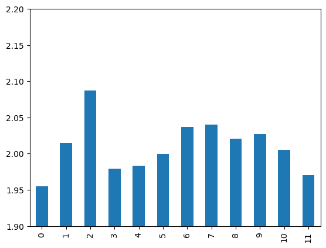

```python
df_ratings['Quarterly Rating'].plot.bar()
#Lets zoom in
plt.ylim(1.9,2.2)
```

```python
df_ratings['Quarterly Rating'].std()
```

```
np.float64(0.03625240841422306)
```

Whatever little variation that is can probably be attributed to weather.

Cold weather months like Dec and Jan have lower ratings - maybe the cars need to have heating along with AC (typically in India, cars dont have this)

## 6.7 Improving the model - Additional data that can be collected which can enable Ola give more insights on its drivers and customers

- Investigate missing data related to total business value
  - We found that 161 drivers have recently joined (2020) but have zero total business value.
  - We find that these drivers have non zero income, infact their avg income is Rs 58908.  
    So surely they are serving the customers.
  - There were 657 more drivers that too joined in 2020 but have non zero total business value.
  - Company can investigate if this is a simple case of missing data or what is the reason for zero business value of these 161 recenly joined drivers.
- Collect or access drive booking level data, which can help us collect these stats

1. Average Pickup distance

2. Cancellation Rate

3. % of delayed pickups

4. % of rides accepted vs. offered

5. Time taken to accept a ride

6. Average idle time between rides

7. % of night or late‑hour drive

8. Count of support tickets per driver

9 .Change in monthly income or incentives

10. Earnings per hour in assigned zones

11. Gaps in online status or off‑duty durations

12. Avg. travel speed per city or time slot

13. % of rides during heavy rain or heat

14. Ratio of corporate / casual customers, weekend vs weekday rides